# Regresión Logística y Descenso de Gradiente

### Asignatura: Machine Learning

### Máster Data Science para Finanzas, CUNEF

### Nombre: Antonio Pascual Hernández

### Fecha: 13 de noviembre de 2020

### Caso Práctico

Suppose that you are an administrator of a university and you want to know the chance of admission of each applicant based on their two exams. You have historical data from previous applicants which can be used as the training data for logistic regression. Your task is to build a classification model that estimates each applicant’s probability of admission in university.

Now, we have understood classification problem that we are going to address. Let us understand the data. In data we have records of previous applicants’ two exams score and label whether applicant got admission or not (1 - if got admission 0 - otherwise).

Cargamos los ficheros que vamos a utilizar:

```python
import numpy as np
import matplotlib.pyplot as plt
import seaborn as sns
import pandas as pd
plt.style.use("ggplot")
%matplotlib inline
```

```python
from pylab import rcParams
rcParams['figure.figsize'] = 12, 8
```

Cargamos los datos:

```python
datos = pd.read_csv('./data/4_1_data.csv', delimiter = ',')
datos.head()
```

|  | score-1 | score-2 | label |
| --- | --- | --- | --- |
| 0 | 34.623660 | 78.024693 | 0 |
| 1 | 30.286711 | 43.894998 | 0 |
| 2 | 35.847409 | 72.902198 | 0 |
| 3 | 60.182599 | 86.308552 | 1 |
| 4 | 79.032736 | 75.344376 | 1 |

La variable score-1 indica la puntuación que un alumno ha obtenido en el examen 1. La variable score-2 indica la puntuación que un alumno ha obtenido en el examen 2. La variable label indica si el alumno ha sido aceptado en la universidad (1) o si ha sido rechazado (0)

```python
datos.info()
```

```
<class 'pandas.core.frame.DataFrame'>
RangeIndex: 100 entries, 0 to 99
Data columns (total 3 columns):
 #   Column   Non-Null Count  Dtype
---  ------   --------------  -----
 0   score-1  100 non-null    float64
 1   score-2  100 non-null    float64
 2   label    100 non-null    int64
dtypes: float64(2), int64(1)
memory usage: 2.5 KB
```

Debemos convertir los datos en valores para poder operar con ellos:

```python
puntuacion = datos[['score-1', 'score-2']].values
resultados = datos['label'].values
```

## Visualizacion

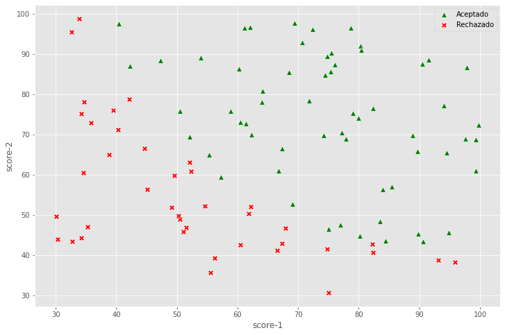

```python
aceptado = (resultados == 1).reshape(100, 1) #aquellas observaciones cuyo valor de la columna label sea 1 serán considerados como aceptados en la universidad
rechazado = (resultados == 0).reshape(100, 1) #aquellas observaciones cuyo valor de la columna label sea 0 serán considerados como rechazados en la universidad

ax = sns.scatterplot(x = puntuacion[aceptado[:, 0], 0],  #se selecciona los valores de la columna 0 que hayan sido aceptados en la universidad
                     y = puntuacion[aceptado[:, 0], 1],  #se selecciona los valores de la columna 1 que hayan sido aceptados en la universidad
                     marker = "^", #se representa, con triangulos verdes, aquellos alumnos que han sido aceptados.
                     color = "green",
                     s = 60)
sns.scatterplot(x = puntuacion[rechazado[:, 0], 0],      #se selecciona los valores de la columna 0 que hayan sido rechazados en la universidad
                y = puntuacion[rechazado[:, 0], 1],      #se selecciona los valores de la columna 1 que hayan sido rechazados en la universidad
                marker = "X",#se representa, con cruces rojas, aquellos alumnos que no han sido aceptados.
                color = "red",
                s = 60)

ax.set(xlabel="score-1", ylabel="score-2") #para indicar los ejes del gráficos
ax.legend(["Aceptado", "Rechazado"]) #para crear la leyenda
plt.show()
```

## Función de costes

La Función de Costes es una función que podemos utilizar para evaluar si nuestro algoritmo mapea la estimación objetivo, o si nuestro algoritmo realiza correctamente problemas de optimización.

En primer lugar, debemos definir la Función Sigmoide:

```python
def logistic_function(x):
    return 1/ (1 + np.exp(-x))
```

Definimos la Funcion de Costes:

```python
def compute_cost(theta, x, y):
    m = len(y)
    y_pred = logistic_function(np.dot(x , theta))
    error = (y * np.log(y_pred)) + ((1 - y) * np.log(1 - y_pred))
    cost = -1 / m * sum(error)
    gradient = 1 / m * np.dot(x.transpose(), (y_pred - y))
    return cost[0] , gradient
```

```python
mean_puntuacion = np.mean(puntuacion, axis=0)
std_puntuacion = np.std(puntuacion, axis=0)
puntuaciones = (puntuacion - mean_puntuacion) / std_puntuacion
rows = puntuaciones.shape[0]
cols = puntuaciones.shape[1]

X = np.append(np.ones((rows, 1)), puntuaciones, axis=1) #include intercept
y = resultados.reshape(rows, 1)

theta_init = np.zeros((cols + 1, 1))
cost, gradient = compute_cost(theta_init, X, y)

print("Cost at initialization", cost)
print("Gradient at initialization:", gradient)
```

```
Cost at initialization 0.693147180559946
Gradient at initialization: [[-0.1       ]
 [-0.28122914]
 [-0.25098615]]
```

El 0.693147180559946 es el con los parámetros iniciales.